# Coursework Report

*N* removed NAs: 2

*N* removed typo: 1

*N* removed <18: 26

*N* total clean: 121

| Group | *N* | *M*<sub>age</sub> | *M*<sub>rating</sub> |
| --- | --- | --- | --- |
| Control | 58 | 20.84 | 6.32 |
| Experim | 63 | 20.92 | 5.90 |

**Main analysis results**

*t*(119) = 2.74, *p* = .007

[interactive chart not shown]

[figure not shown]

[interactive chart not shown]

# Coursework Report

Analysing Data, Spring 2020

### Methods

##### Participants

Table 1 *descriptive statistics of age by condition*

| Condition | *N* | % | *M*<sub>age</sub> | *SD*<sub>age</sub> | *MIN*<sub>age</sub> | *MAX*<sub>age</sub> | *R*<sub>ange</sub> |
| --- | --- | --- | --- | --- | --- | --- | --- |
| control | 58 | 47.93 | 20.84 | 2 | 18 | 28 | 10 |
| experimental | 63 | 52.07 | 20.92 | 2 | 18 | 26 | 8 |

### Design

The conceptual hypothesis for this study is “Does colour influence attractiveness?”. The participants saw one of two pictures in a frame. The control group saw the picture in a white frame and the experimental group in a red frame. Attractiveness was rated on a rating scale from 1-9 on three questions: how attractive do you think this person is? How pleasant is this person to look at? If I were to the person in this picture face to face, would I think he is attractive? The answers to these three questions were then averaged to get a composite score. The rating scale is interpreted as 1 being unattractive and 9 being very attractive. The statistical analysis used to test this hypothesis will be a t-test.

### Results

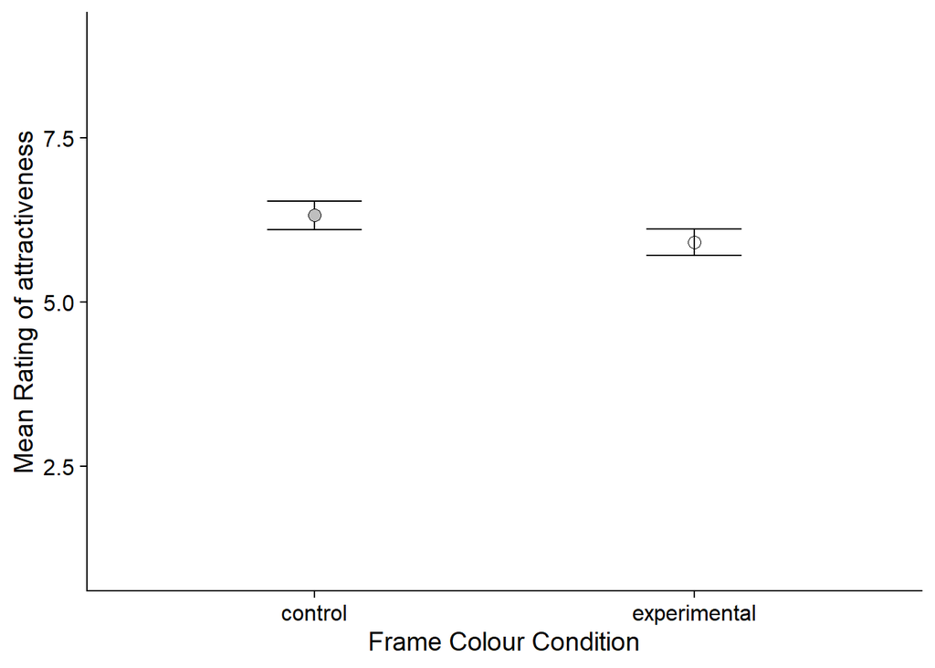

It was investigated whether colour has an on ratings of attractiveness as measured by an independent measures t-test. The difference in means for the control and experimental conditions were 0.42 95% CI [0.12 0.72]. It can be concluded that there was a significant difference between the ratings of attractiveness between the two groups (*t*) (119) = 2.74, *p* = 0.01). Thus, the results suggest that colour does have an effect in that red makes people less attractive due to the lower ratings for attractiveness as shown by the figure above.

### Discussion

The effect of colour on attractiveness ratings is a well-researched area. The results of the study illustrated that colour does have an influence on attractiveness with the person in the picture shown to participants being deemed as more attractive in the white frame condition. Therefore, the colour red does not show to increase attractiveness. This differs from the study by Elliot (2010) although both their study and this study found an effect of colour on attractiveness, the study by Elliot et al found that red influenced attractiveness ratings whereas this study found that red did not make the person in the picture be rated as more attractive. This means, for the effect this study is investigating, the results are useful in interpreting whether colour influences attractiveness because they show the same effect of just with differing views with the colour red’s effect on attractiveness specifically. In terms of similar studies, a study by Young (2015) illustrated that the colour red had an effect on attractiveness rating on photos of women that were pre-rated as attractive by men (Young, 2015). This can be compared to this study because it is demonstrating the effect of colour on attractiveness ratings but it differs in that the pictures were of women whereas our study used a photo of a male with either a white or red frame. This study by Young brings the question of what is attractieveness and what is it that allows someone to be pre-rated as attractive? This is something that our replicated study has not covered in that the photos were not pre-rated and is something to think about for further research. Perhaps, by adding a qualitative element to the study by asking people what makes the person attractive and see if that differs between colours.

Another study that can be comapred to this replacation of Elliot et al’s study is a study by Hessingler et al (2015) which can be used as a stronger comparison to this study because they found a similar pattern of results in that red did not have an effect on the photos of the males which was the same gender as our study in the photos. However, this study added a further variable in changing the clothing-style the males were wearing in the photos, although the colour red still did not have a significant effect on attractiveness (Hessingler et al, 2015). This further supports our pattern of results because the colour red was not found to increase attractiveness ratings. Adding the clothing variable was an interesting element to this study because this gives this study more ecological validity as men do not wear the same type of clothes all the time in real life. A strength of the study we carried out was that real-world applications in that who we find attractive is important for mating. For example, a study by Hill & Durante (2011) found that women were more likely to take part in risky attractiveness-enhancing behaviour, when primed by intersexual courtship and intrasexual competition, such as diet pills and tanning for the sake of attractiveness-enhancement goals linked to mating. This relates to our study because if women are taking part in risky behaviour for attractiveness when their percieved attractiveness could be changed by something much less risky such as different colours, then this research can be applied into reducing this kind of behaviour. Another strength is that the study was not gender-specific for those rating the attractiveness. This could then enhance the ecological validity of the study because then it can be argued that it does not just apply to attractiveness associated with mating goals. This gives it further room to be researched further in understanding the reasons for the participant’s ratings of attractiveness. On the other hand, this is a limitation of the study in that it does not take into account sexuality. Can it be a valid rating of attrativeness if someone who is not attracted to any males despite the colour of the frame? To solve this problem, further research could include a questionnaire of sexuality and then be assigned a photo with different coloured frames based on that. Evidence from Ha et al (2011) found that heterosexual men and women and homosexual men and women have similar preferences in their mating goals. Therefore, adding these further participant variables to the study would increase the validity of the attractiveness ratings. It is a strength that the study had a well-replicable independent variable of the red or white frame which allows for easier replication for further research to determine the influence of colour on attractiveness ratings.

### Conclusion

In sum, the findings of this study found that there was an influence of colour on attractiveness but not in the same fashion as the study that this study attempted to replicate, in that red did not increase attractiveness. Rather, the red frame was found to be rated as less attractive compared to the white framed photo. This provides room for further research on colour and attractiveness to understand, perhaps, how colour influences attractiveness ratings. It is an important phenomenon to consider due to how relevant attractiveness is for life in mating and competition as shown by the studies in the discussion. Sexuality must also be considered for further research because this has implications for the validity of the response to the attractiveness rating questions. Attractiveness itself is also a fluid concept so there will always be some leeway for interpretation. Overall, the study had clear defined variables and provides another body of evidence to the research area of colour and the influence on attractiveness.

### References

Elliot, A., Niesta Kayser, D., Greitemeyer, T., Lichtenfeld, S., Gramzow, R., Maier, M., & Liu, H. (2010). Red, rank, and romance in women viewing men. Journal Of Experimental Psychology: General, 139(3), 399-417. doi: 10.1037/a0019689

Ha, T., van den Berg, J., Engels, R., & Lichtwarck-Aschoff, A. (2011). Effects of Attractiveness and Status in Dating Desire in Homosexual and Heterosexual Men and Women. Archives Of Sexual Behavior, 41(3), 673-682. doi: 10.1007/s10508-011-9855-9

Hesslinger, V., Goldbach, L., & Carbon, C. (2015). Men in red: A reexamination of the red-attractiveness effect. Psychonomic Bulletin & Review, 22(4), 1142-1148. doi: 10.3758/s13423-015-0866-8

Hill, S., & Durante, K. (2011). Courtship, Competition, and the Pursuit of Attractiveness: Mating Goals Facilitate Health-Related Risk Taking and Strategic Risk Suppression in Women. Personality And Social Psychology Bulletin, 37(3), 383-394. doi: 10.1177/0146167210395603

Young, S. (2015). The effect of red on male perceptions of female attractiveness: Moderation by baseline attractiveness of female faces. European Journal Of Social Psychology, 45(2), 146-151. doi: 10.1002/ejsp.2098